# Temperature analyses

## 4.6 Plotting corrected vs raw temperatures

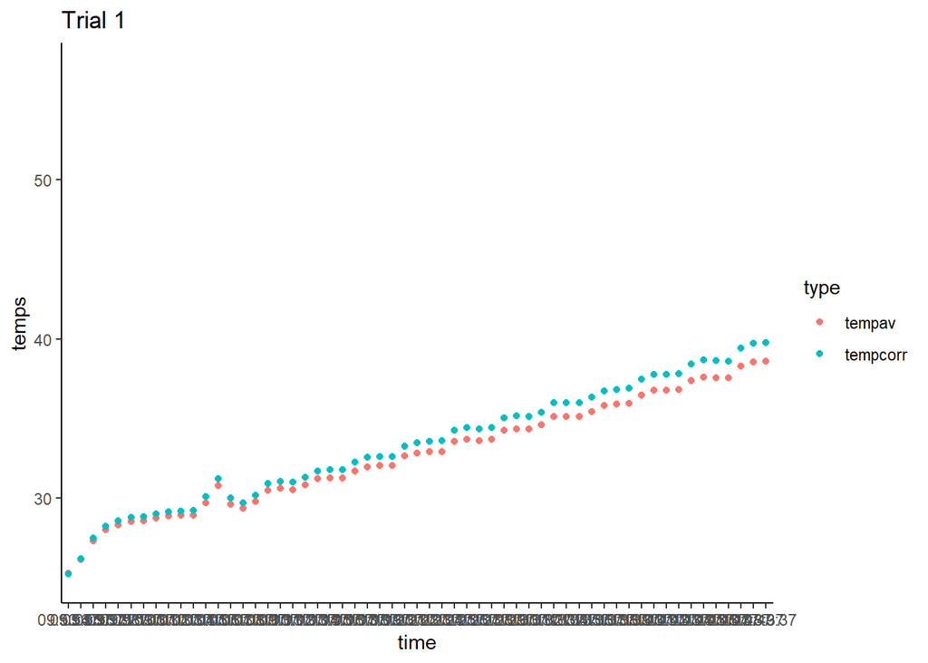

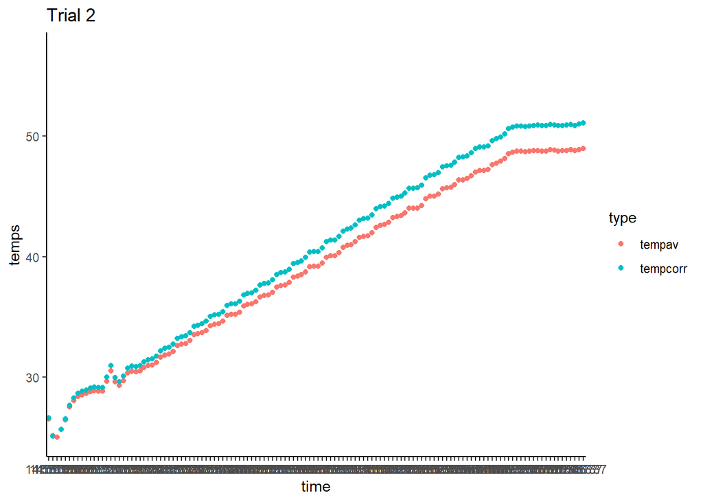

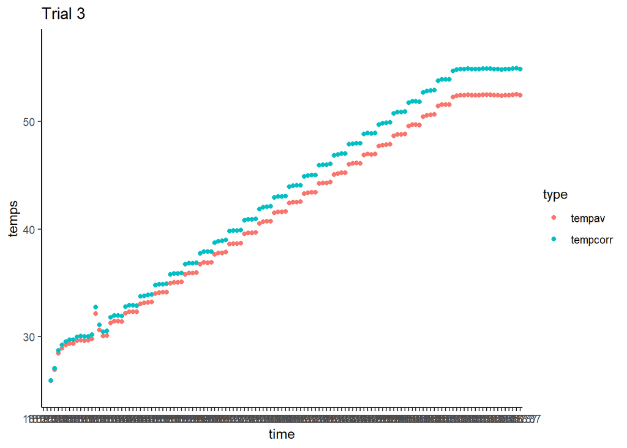

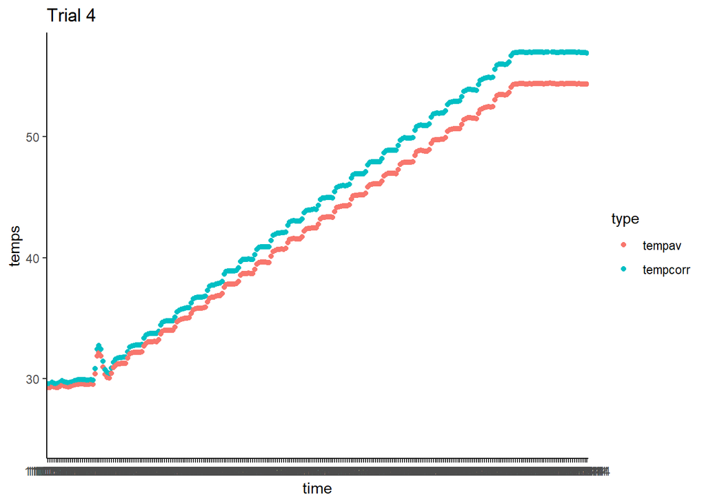

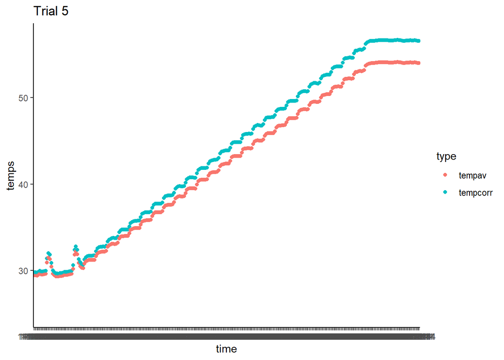

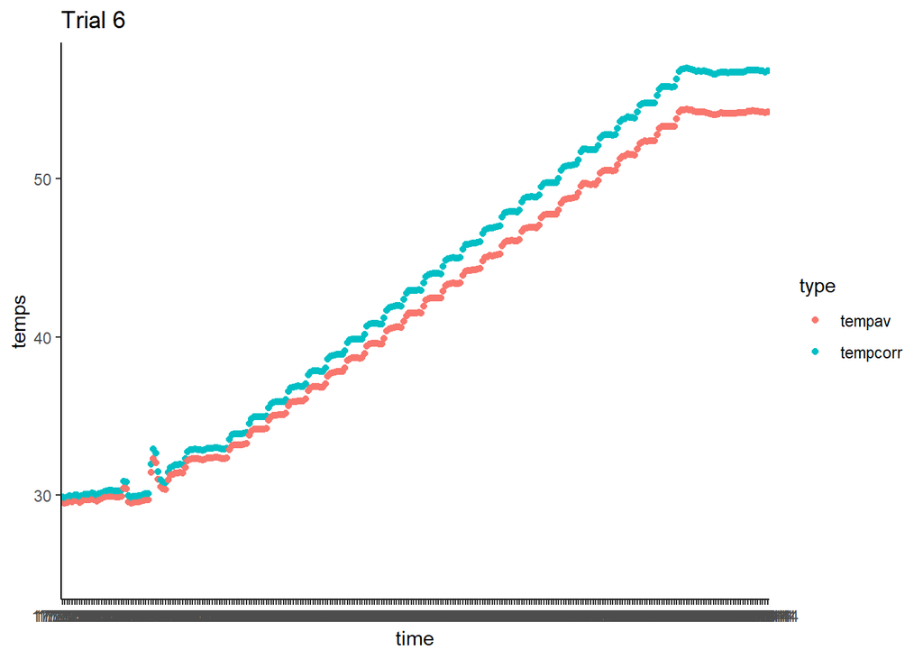

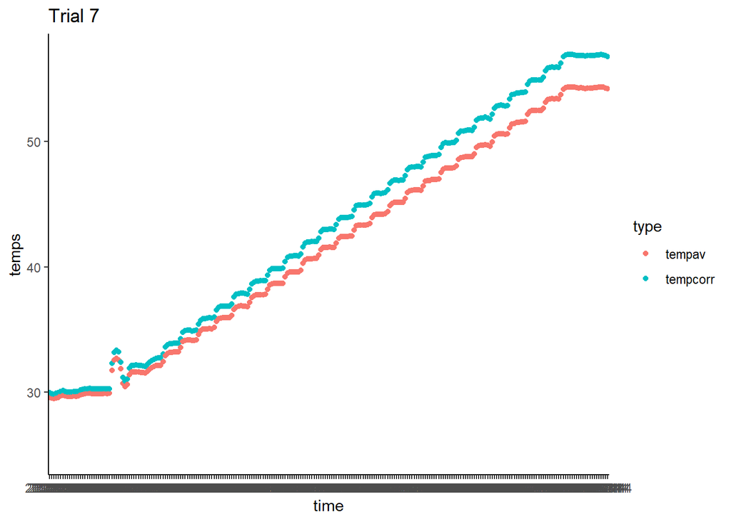

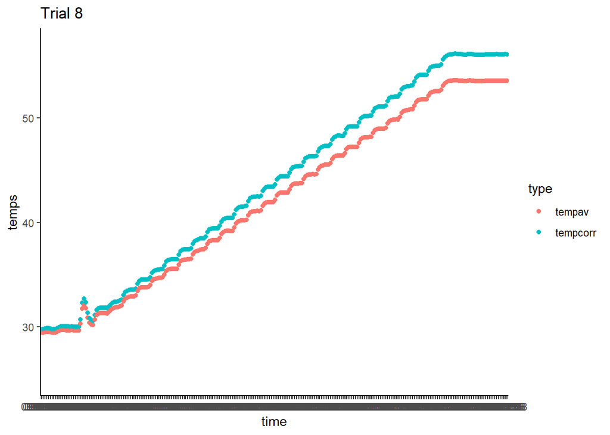

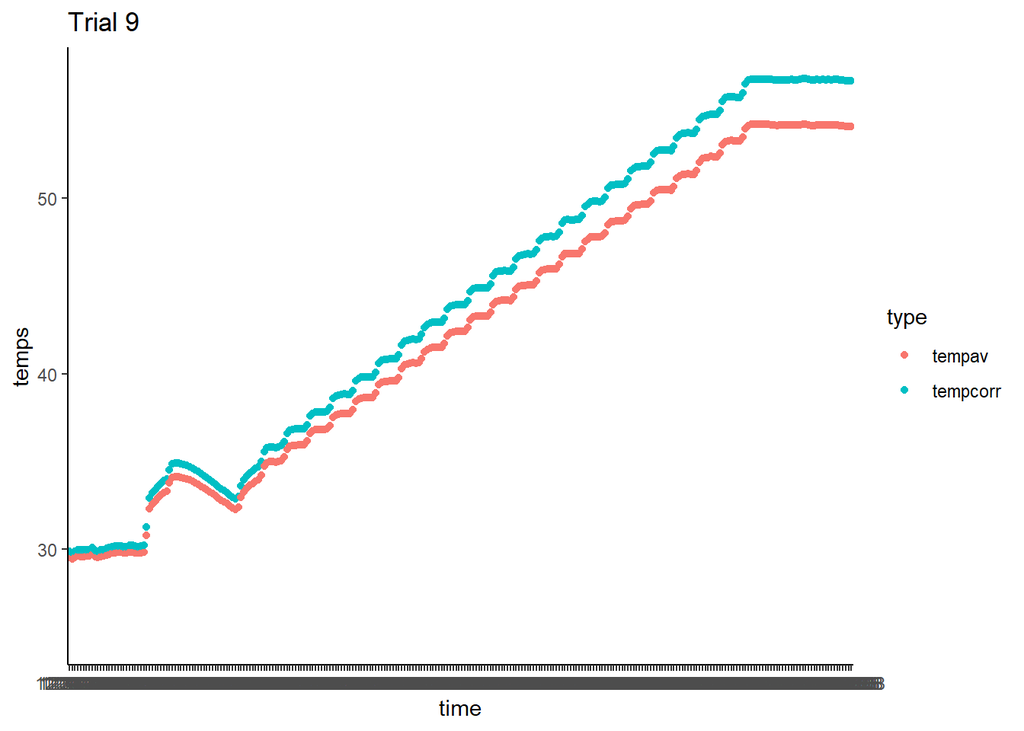

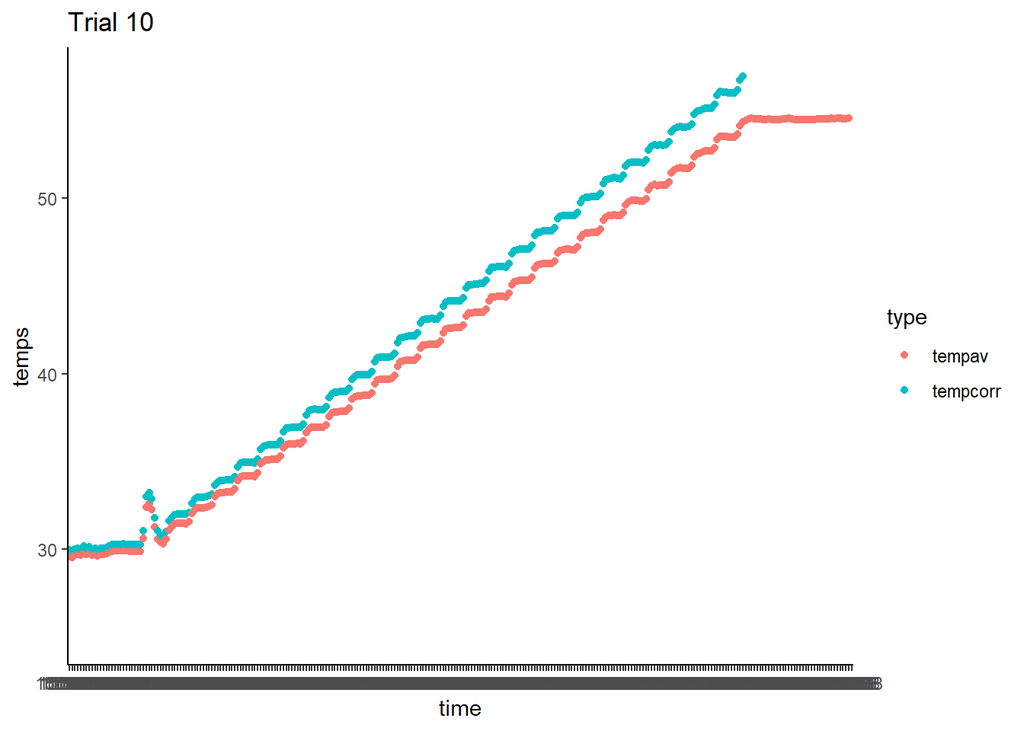

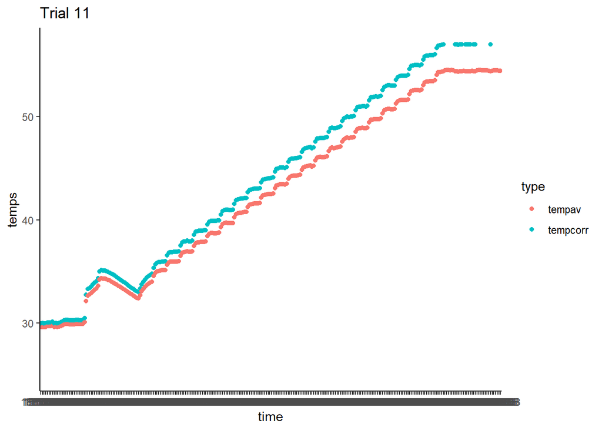

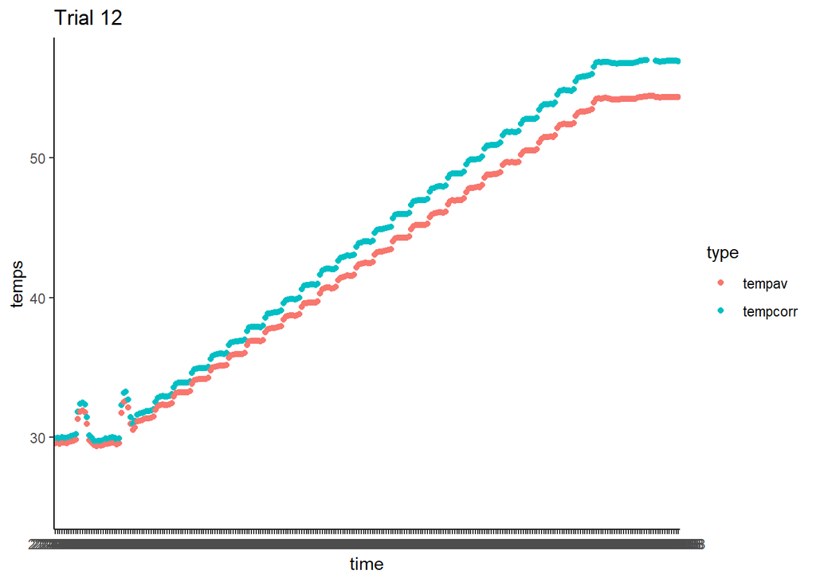

[1 more figures not shown]

```r
p1<-all_corr %>%
  filter(trial==1) %>%
  pivot_longer(cols=c("tempav", "tempcorr"), values_to="temps", names_to = "type")%>%
  ggplot(.,aes(x=time,y=temps, color=type))+
  geom_point()+theme_classic()+ylim(25,57)+ ggtitle("Trial 1")
p1

p2<-all_corr %>%
  filter(trial==2) %>%
  pivot_longer(cols=c("tempav", "tempcorr"), values_to="temps", names_to = "type")%>%
  ggplot(.,aes(x=time,y=temps, color=type))+
  geom_point()+theme_classic()+ylim(25,57)+ ggtitle("Trial 2")
p2

p3<-all_corr %>%
  filter(trial==3) %>%
  pivot_longer(cols=c("tempav", "tempcorr"), values_to="temps", names_to = "type")%>%
  ggplot(.,aes(x=time,y=temps, color=type))+
  geom_point()+theme_classic()+ylim(25,57)+ ggtitle("Trial 3")
p3

p4<-all_corr %>%
  filter(trial==4) %>%
  pivot_longer(cols=c("tempav", "tempcorr"), values_to="temps", names_to = "type")%>%
  ggplot(.,aes(x=time,y=temps, color=type))+
  geom_point()+theme_classic()+ylim(25,57)+ ggtitle("Trial 4")
p4


p5<-all_corr %>%
  filter(trial==5) %>%
  pivot_longer(cols=c("tempav", "tempcorr"), values_to="temps", names_to = "type")%>%
  ggplot(.,aes(x=time,y=temps, color=type))+
  geom_point()+theme_classic()+ylim(25,57)+ ggtitle("Trial 5")
p5

p6<-all_corr %>%
  filter(trial==6) %>%
  pivot_longer(cols=c("tempav", "tempcorr"), values_to="temps", names_to = "type")%>%
  ggplot(.,aes(x=time,y=temps, color=type))+
  geom_point()+theme_classic()+ylim(25,57)+ ggtitle("Trial 6")
p6

p7<-all_corr %>%
  filter(trial==7) %>%
  pivot_longer(cols=c("tempav", "tempcorr"), values_to="temps", names_to = "type")%>%
  ggplot(.,aes(x=time,y=temps, color=type))+
  geom_point()+theme_classic()+ylim(25,57)+ ggtitle("Trial 7")
p7

p8<-all_corr %>%
  filter(trial==8) %>%
  pivot_longer(cols=c("tempav", "tempcorr"), values_to="temps", names_to = "type")%>%
  ggplot(.,aes(x=time,y=temps, color=type))+
  geom_point()+theme_classic()+ylim(25,57)+ ggtitle("Trial 8")
p8

p9<-all_corr %>%
  filter(trial==9) %>%
  pivot_longer(cols=c("tempav", "tempcorr"), values_to="temps", names_to = "type")%>%
  ggplot(.,aes(x=time,y=temps, color=type))+
  geom_point()+theme_classic()+ylim(25,57)+ ggtitle("Trial 9")
p9

p10<-all_corr %>%
  filter(trial==10) %>%
  pivot_longer(cols=c("tempav", "tempcorr"), values_to="temps", names_to = "type")%>%
  ggplot(.,aes(x=time,y=temps, color=type))+
  geom_point()+theme_classic()+ylim(25,57)+ ggtitle("Trial 10")
p10

p11<-all_corr %>%
  filter(trial==11) %>%
  pivot_longer(cols=c("tempav", "tempcorr"), values_to="temps", names_to = "type")%>%
  ggplot(.,aes(x=time,y=temps, color=type))+
  geom_point()+theme_classic()+ylim(25,57)+ ggtitle("Trial 11")
p11

p12<-all_corr %>%
  filter(trial==12) %>%
  pivot_longer(cols=c("tempav", "tempcorr"), values_to="temps", names_to = "type")%>%
  ggplot(.,aes(x=time,y=temps, color=type))+
  geom_point()+theme_classic()+ylim(25,57)+ ggtitle("Trial 12")
p12

p13<-all_corr %>%
  filter(trial==13) %>%
  pivot_longer(cols=c("tempav", "tempcorr"), values_to="temps", names_to = "type")%>%
  ggplot(.,aes(x=time,y=temps, color=type))+
  geom_point()+theme_classic()+ylim(25,57)+ ggtitle("Trial 13")
p13
```

# 5 Saving workspace file

```r
#save(list = ls(.GlobalEnv), file = "Outputs/Temperature analyses.RData") #saves all the objects in the global environment
save(all_corr,file = "Outputs/Temperature analyses.RData")
```

# 6 Behavioral trials thermolimit

## 6.1 Reading files

```r
cnames<-c("#", "datetime", "temp1", "temp2", "detached", "attached", "connected", "end","x")

tb<-read.csv("Data/Temperature/Thermal_block_test.csv", skip=2, header=F, col.names=cnames)

head(tb)
```

|  | X. | datetime | temp1 | temp2 | detached | attached | connected | end | x |
| --- | --- | --- | --- | --- | --- | --- | --- | --- | --- |
| 1 | 1 | 10/19/22 11:20:18 AM | 30.217 | 27.358 |  |  | NA | NA | NA |
| 2 | 2 | 10/19/22 11:20:24 AM | NA | NA | Logged |  | NA | NA | NA |
| 3 | 3 | 10/19/22 11:20:48 AM | 28.568 | 26.720 |  |  | NA | NA | NA |
| 4 | 4 | 10/19/22 11:21:18 AM | 26.207 | 25.307 |  |  | NA | NA | NA |
| 5 | 5 | 10/19/22 11:21:48 AM | 25.258 | 24.750 |  |  | NA | NA | NA |
| 6 | 6 | 10/19/22 11:22:18 AM | 24.726 | 24.412 |  |  | NA | NA | NA |

## 6.2 Organizing and adding data

```r
tb2<- tb %>%
  select(1:4) %>% #removing non-relevant columns
  na.omit() %>% #removing NAs
  mutate(datetime=as_datetime(datetime, format="%m/%d/%y %I:%M:%S %p")) %>% #converting the datetime column from character into a datetime format
  separate(datetime, c("date", "time"), remove=FALSE, sep=" ") %>% #separating date and time into two columns
    mutate(date=ymd(date), #formatting date
         tempav=rowMeans(.[,5:6]), #calculating averages for the two temperature sensors
        trial=case_when(datetime >= ymd_hms("2022-10-19 11:32:00") &
                               datetime <= ymd_hms("2022-10-19 13:55:00")~1, #Assigning trial 1
                        datetime >= ymd_hms("2022-10-19 14:15:00") &
                               datetime <= ymd_hms("2022-10-19 16:36:00")~2,#Assigning trial 2
                        datetime >= ymd_hms("2022-10-19 16:46:00") &
                               datetime <= ymd_hms("2022-10-19 19:03:00")~3,#Assigning trial 3
                        datetime >= ymd_hms("2022-10-20 13:33:00") &
                               datetime <= ymd_hms("2022-10-20 15:51:00")~4,#Assigning trial 4
                        datetime >= ymd_hms("2022-10-20 16:10:00") &
                               datetime <= ymd_hms("2022-10-20 18:32:00")~5,#Assigning trial 5
                        datetime >= ymd_hms("2022-10-21 10:08:00") &
                               datetime <= ymd_hms("2022-10-21 12:17:00")~6,#Assigning trial 6
                        datetime >= ymd_hms("2022-10-22 13:32:00") &
                               datetime <= ymd_hms("2022-10-22 15:53:00")~7,#Assigning trial 7
                        datetime >= ymd_hms("2022-10-22 16:01:00") &
                               datetime <= ymd_hms("2022-10-22 18:23:00")~8,#Assigning trial 8
                        TRUE~0)) %>%
  mutate(datetime2=round_date(datetime, unit="minute")) #creating a coluns of datetime rounded by minutes to facilitate merging later
```

## 6.3 Creating dataframe for thermocouple variables

```r
# Trial 1
trial<-rep(1)
datetime<-c("2022-10-19 11:35:00", "2022-10-19 11:41:00","2022-10-19 11:46:00","2022-10-19 11:53:00","2022-10-19 12:04:00","2022-10-19 12:17:00","2022-10-19 12:27:00","2022-10-19 12:38:00","2022-10-19 12:49:00","2022-10-19 12:57:00","2022-10-19 13:07:00","2022-10-19 13:27:00","2022-10-19 13:28:00")
tempblock<-c(30,30,29,34,35,39,41,44,47,49,51,56,56)
tempcouple<-c(24.4,28.2,28.3,33.9, 34.2,38,40,43.3,45.8, 47.5,50,54.8,54.8)

t1<-data.frame(trial, datetime,tempblock, tempcouple)
t1<-t1%>%
  mutate(datetime2=ymd_hms(datetime))

# Trial 2
trial<-rep(2)
datetime<-c("2022-10-19 14:19:00", "2022-10-19 14:25:00","2022-10-19 14:35:00","2022-10-19 14:55:00","2022-10-19 15:15:00","2022-10-19 15:36:00","2022-10-19 15:56:00","2022-10-19 16:11:00")
tempblock<-c(30,30,35, 37, 43, 48, 53,56)
tempcouple<-c(28.3, 28.6, 34.3, 36.2, 41.5, 46.7, 51.7, 54.7)

t2<-data.frame(trial, datetime,tempblock, tempcouple)
t2<-t2%>%
  mutate(datetime2=ymd_hms(datetime))

# Trial 3
trial<-rep(3)
datetime<-c("2022-10-19 16:46:00", "2022-10-19 16:56:00","2022-10-19 17:19:00","2022-10-19 17:42:00","2022-10-19 18:02:00","2022-10-19 18:22:00","2022-10-19 18:45:00")
tempblock<-c(27,30,35,41,46,51,56)
tempcouple<-c(25.2,28.7,34.1,40,45.1,49.9,54.7)

t3<-data.frame(trial, datetime,tempblock, tempcouple)
t3<-t3%>%
  mutate(datetime2=ymd_hms(datetime))

# Trial 4
trial<-rep(4)
datetime<-c("2022-10-20 13:44:00", "2022-10-20 14:05:00","2022-10-20 14:26:00","2022-10-20 14:46:00","2022-10-20 15:08:00","2022-10-20 15:27:00")
tempblock<-c(30,35,40,45,51,55)
tempcouple<-c(28.5,33.6,39.1, 44.1, 49.5, 53.7)

t4<-data.frame(trial, datetime,tempblock, tempcouple)
t4<-t4%>%
  mutate(datetime2=ymd_hms(datetime))

# Trial 5
trial<-rep(5)
datetime<-c("2022-10-20 16:24:00", "2022-10-20 16:46:00","2022-10-20 17:11:00","2022-10-20 17:32:00","2022-10-20 17:52:00","2022-10-20 18:12:00")
tempblock<-c(30,35,41,47,52,57)
tempcouple<-c(28.5,34.2,40.1,45.9, 50.6, 55.7)

t5<-data.frame(trial, datetime,tempblock, tempcouple)
t5<-t5%>%
  mutate(datetime2=ymd_hms(datetime))


# Trial 6
trial<-rep(6)
datetime<-c("2022-10-21 10:18:00", "2022-10-21 10:44:00","2022-10-21 11:05:00","2022-10-21 11:25:00","2022-10-21 11:46:00","2022-10-21 12:06:00")
tempblock<-c(30,36,41,46,51,56)
tempcouple<-c(28.6,35.4,40.2, 45, 49.9,54.8)

t6<-data.frame(trial, datetime,tempblock, tempcouple)
t6<-t6%>%
  mutate(datetime2=ymd_hms(datetime))

# Trial 7
trial<-rep(7)
datetime<-c("2022-10-22 13:43:00", "2022-10-22 14:05:00","2022-10-22 14:26:00","2022-10-22 14:45:00","2022-10-22 15:06:00","2022-10-22 15:26:00","2022-10-22 15:30:00")
tempblock<-c(30,34,40,45,50,55,56)
tempcouple<-c(28.5,33.4,39,44,48.8,53.8,54.6)

t7<-data.frame(trial, datetime,tempblock, tempcouple)
t7<-t7%>%
  mutate(datetime2=ymd_hms(datetime))


# Trial 8
trial<-rep(8)
datetime<-c("2022-10-22 16:12:00", "2022-10-22 16:33:00","2022-10-22 16:53:00","2022-10-22 17:13:00","2022-10-22 17:36:00","2022-10-22 17:57:00","2022-10-22 18:00:00")
tempblock<-c(30,35,40,45,50,56,56)
tempcouple<-c(28.3,34.4,38.3,42.7,47.6,53.0,53.3)

t8<-data.frame(trial, datetime,tempblock, tempcouple)
t8<-t8%>%
  mutate(datetime2=ymd_hms(datetime))

#Merging all into a single frame
couples<-bind_rows(t1,t2,t3,t4,t5,t6,t7,t8)

head(couples)
```

|  | trial | datetime | tempblock | tempcouple | datetime2 |
| --- | --- | --- | --- | --- | --- |
| 1 | 1 | 2022-10-19 11:35:00 | 30 | 24.4 | 2022-10-19 11:35:00 |
| 2 | 1 | 2022-10-19 11:41:00 | 30 | 28.2 | 2022-10-19 11:41:00 |
| 3 | 1 | 2022-10-19 11:46:00 | 29 | 28.3 | 2022-10-19 11:46:00 |
| 4 | 1 | 2022-10-19 11:53:00 | 34 | 33.9 | 2022-10-19 11:53:00 |
| 5 | 1 | 2022-10-19 12:04:00 | 35 | 34.2 | 2022-10-19 12:04:00 |
| 6 | 1 | 2022-10-19 12:17:00 | 39 | 38.0 | 2022-10-19 12:17:00 |

## 6.4 Merging loggers and thermocouple data into a single dataframe

```r
all<-full_join(tb2, couples, by=c("datetime2","trial"), suffix=c("", ".cb"))
head(all)
```

|  | X. | datetime | date | time | temp1 | temp2 | tempav | trial | datetime2 | datetime.cb | tempblock | tempcouple |
| --- | --- | --- | --- | --- | --- | --- | --- | --- | --- | --- | --- | --- |
| 1 | 1 | 2022-10-19 11:20:18 | 2022-10-19 | 11:20:18 | 30.217 | 27.358 | 28.7875 | 0 | 2022-10-19 11:20:00 | NA | NA | NA |
| 2 | 3 | 2022-10-19 11:20:48 | 2022-10-19 | 11:20:48 | 28.568 | 26.720 | 27.6440 | 0 | 2022-10-19 11:21:00 | NA | NA | NA |
| 3 | 4 | 2022-10-19 11:21:18 | 2022-10-19 | 11:21:18 | 26.207 | 25.307 | 25.7570 | 0 | 2022-10-19 11:21:00 | NA | NA | NA |
| 4 | 5 | 2022-10-19 11:21:48 | 2022-10-19 | 11:21:48 | 25.258 | 24.750 | 25.0040 | 0 | 2022-10-19 11:22:00 | NA | NA | NA |
| 5 | 6 | 2022-10-19 11:22:18 | 2022-10-19 | 11:22:18 | 24.726 | 24.412 | 24.5690 | 0 | 2022-10-19 11:22:00 | NA | NA | NA |
| 6 | 7 | 2022-10-19 11:22:48 | 2022-10-19 | 11:22:48 | 24.412 | 24.195 | 24.3035 | 0 | 2022-10-19 11:23:00 | NA | NA | NA |

# 7 Exploring data

## 7.1 Looking at the differences between loggers, thermalblock and thermocouple

```r
diffs<-all %>%
  mutate(diffblock=tempblock-tempav,
         diffcouple=tempcouple-tempav) %>%
  na.omit()

head(diffs)
```

|  | X. | datetime | date | time | temp1 | temp2 | tempav | trial | datetime2 | datetime.cb | tempblock | tempcouple | diffblock | diffcouple |
| --- | --- | --- | --- | --- | --- | --- | --- | --- | --- | --- | --- | --- | --- | --- |
| 30 | 31 | 2022-10-19 11:34:48 | 2022-10-19 | 11:34:48 | 25.016 | 25.574 | 25.2950 | 1 | 2022-10-19 11:35:00 | 2022-10-19 11:35:00 | 30 | 24.4 | 4.7050 | -0.8950 |
| 31 | 32 | 2022-10-19 11:35:18 | 2022-10-19 | 11:35:18 | 26.061 | 26.549 | 26.3050 | 1 | 2022-10-19 11:35:00 | 2022-10-19 11:35:00 | 30 | 24.4 | 3.6950 | -1.9050 |
| 42 | 43 | 2022-10-19 11:40:48 | 2022-10-19 | 11:40:48 | 28.023 | 28.543 | 28.2830 | 1 | 2022-10-19 11:41:00 | 2022-10-19 11:41:00 | 30 | 28.2 | 1.7170 | -0.0830 |
| 43 | 44 | 2022-10-19 11:41:18 | 2022-10-19 | 11:41:18 | 27.998 | 28.468 | 28.2330 | 1 | 2022-10-19 11:41:00 | 2022-10-19 11:41:00 | 30 | 28.2 | 1.7670 | -0.0330 |
| 52 | 53 | 2022-10-19 11:45:48 | 2022-10-19 | 11:45:48 | 29.265 | 29.464 | 29.3645 | 1 | 2022-10-19 11:46:00 | 2022-10-19 11:46:00 | 29 | 28.3 | -0.3645 | -1.0645 |
| 53 | 54 | 2022-10-19 11:46:18 | 2022-10-19 | 11:46:18 | 30.773 | 30.900 | 30.8365 | 1 | 2022-10-19 11:46:00 | 2022-10-19 11:46:00 | 29 | 28.3 | -1.8365 | -2.5365 |

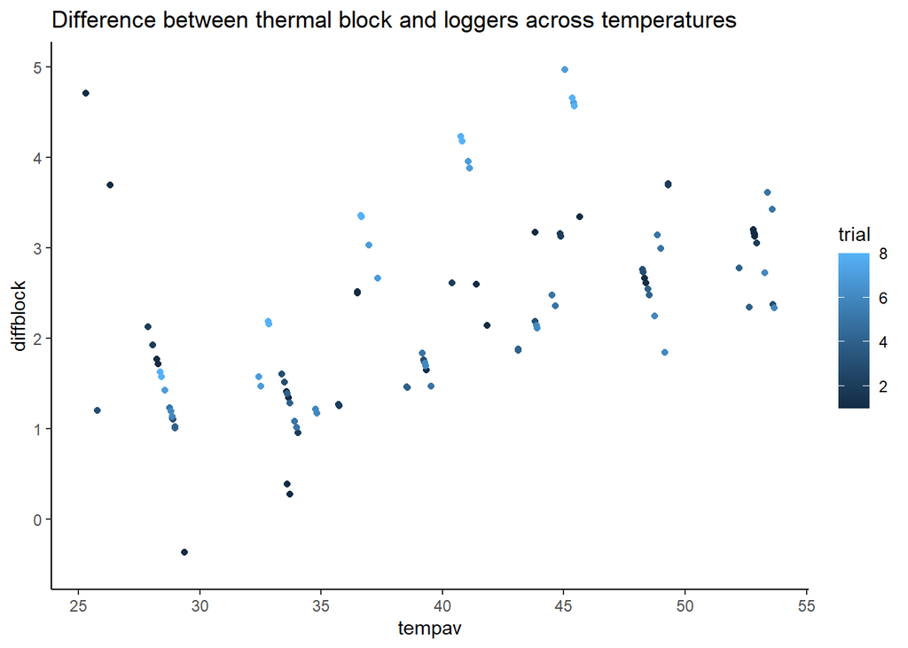

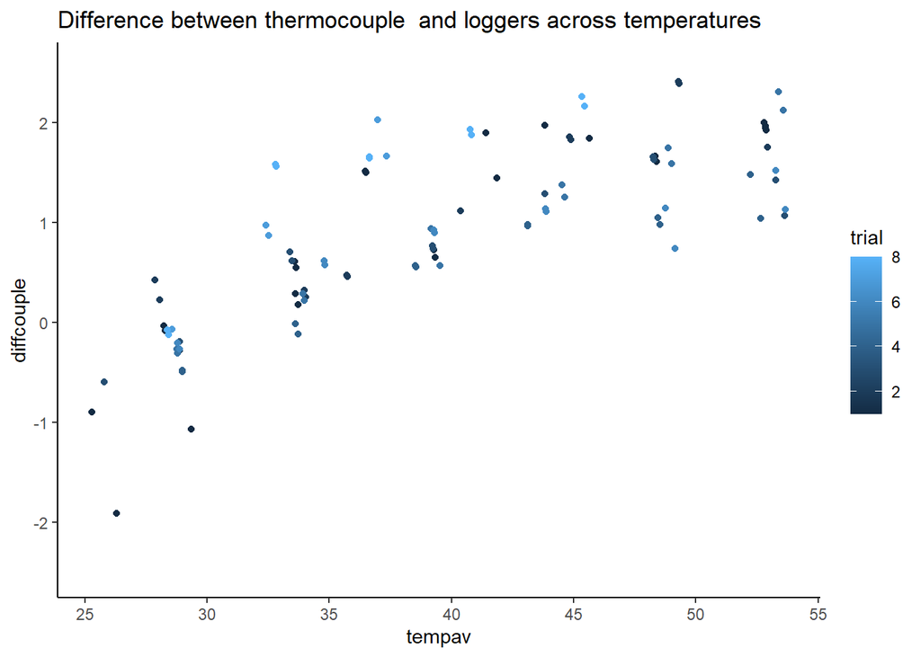

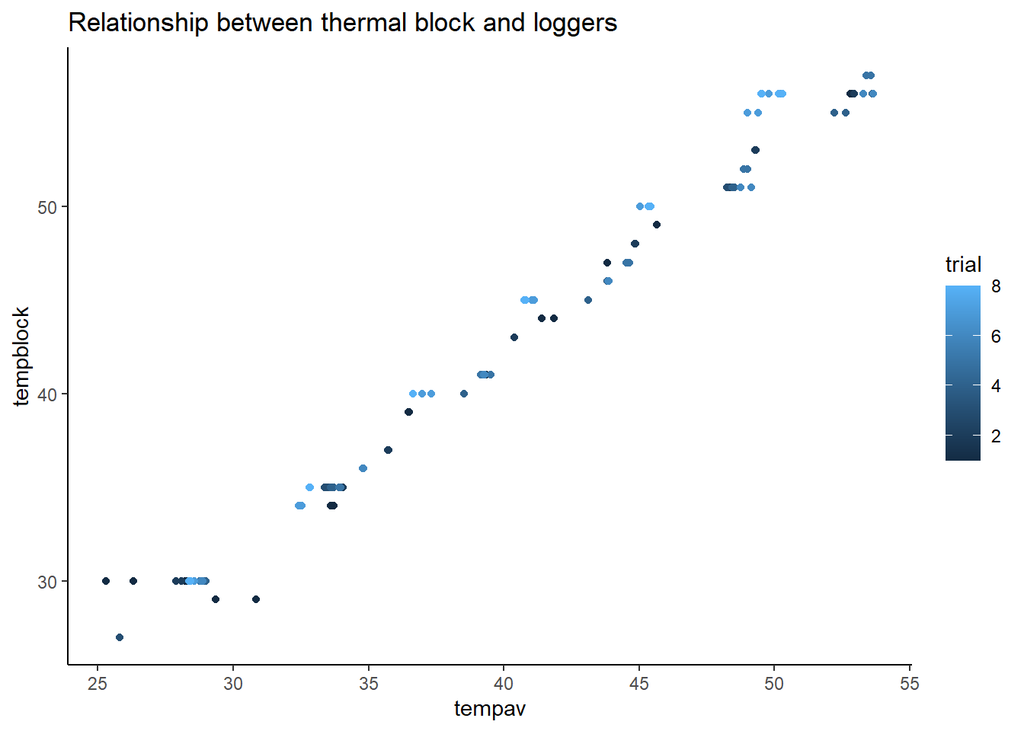

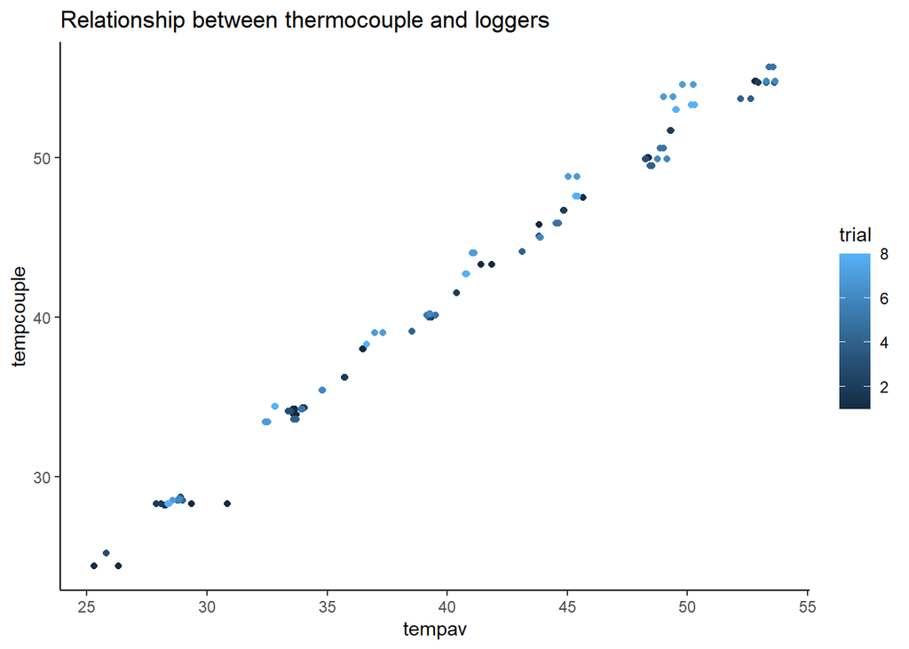

```r
ggplot(diffs, aes(x=tempav,y=diffblock, color=trial))+
  geom_point()+ylim(-0.5,5) +theme_classic()+ggtitle("Difference between thermal block and loggers across temperatures")

ggplot(diffs, aes(x=tempav,y=diffcouple, color=trial))+
  geom_point()+ylim(-2.5,2.55)+theme_classic()+ggtitle("Difference between thermocouple  and loggers across temperatures")

ggplot(diffs, aes(x=tempav,y=tempblock, color=trial))+
  geom_point()+theme_classic()+ggtitle("Relationship between thermal block and loggers")

ggplot(diffs, aes(x=tempav,y=tempcouple, color=trial))+
  geom_point()+theme_classic()+ggtitle("Relationship between thermocouple and loggers")
```

***

> I think using the block temperatures would be better to correct the logger temperatures because:
1. The block sensor is always in the same position, but the thermocouple wire might have been placed on different spots or moved in between trials
2. The thermal block was done to keep track of specific temperatures to do PCRs, etc, therefore, it should be fairly accurate on how much the samples were heat up

#Correcting data

## 7.2 Estimating the slope to correct the logger temperatures

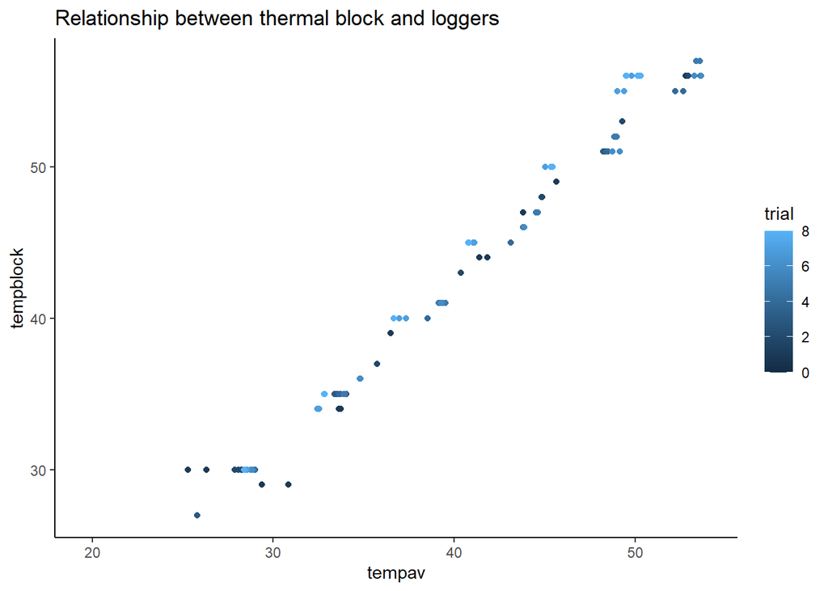

```r
ggplot(all, aes(x=tempav,y=tempblock, color=trial))+
  geom_point()+theme_classic()+ggtitle("Relationship between thermal block and loggers")
```

```r
lm1<-lm(tempblock~tempav, data=all)
lm1
```

```
##
## Call:
## lm(formula = tempblock ~ tempav, data = all)
##
## Coefficients:
## (Intercept)       tempav
##      -1.628        1.102
```

```r
slope<-lm1$coefficients[2]
int<-lm1$coefficients[1]
```

> As it is a linear relationship, I can now correct the loggers temps (x) to get the block temperature by using the formula:

$$\begin{align*}
y=m&x+b \\
o&r \\
block temperature = slope * l&ogger temperature + intercept \\
\end{align*}$$

## 7.3 Correcting the temperatures for each trial

```r
# Removing trial 0 and correcting all other temperatures
all_corr<-all%>%
  filter(trial!=0) %>%
  mutate(tempcorr=(slope*tempav)+int)

head(all_corr)
```

|  | X. | datetime | date | time | temp1 | temp2 | tempav | trial | datetime2 | datetime.cb | tempblock | tempcouple | tempcorr |
| --- | --- | --- | --- | --- | --- | --- | --- | --- | --- | --- | --- | --- | --- |
| 1 | 26 | 2022-10-19 11:32:18 | 2022-10-19 | 11:32:18 | 23.809 | 24.484 | 24.1465 | 1 | 2022-10-19 11:32:00 | NA | NA | NA | 24.98365 |
| 2 | 27 | 2022-10-19 11:32:48 | 2022-10-19 | 11:32:48 | 23.376 | 24.002 | 23.6890 | 1 | 2022-10-19 11:33:00 | NA | NA | NA | 24.47945 |
| 3 | 28 | 2022-10-19 11:33:18 | 2022-10-19 | 11:33:18 | 23.400 | 24.002 | 23.7010 | 1 | 2022-10-19 11:33:00 | NA | NA | NA | 24.49267 |
| 4 | 29 | 2022-10-19 11:33:48 | 2022-10-19 | 11:33:48 | 23.833 | 24.363 | 24.0980 | 1 | 2022-10-19 11:34:00 | NA | NA | NA | 24.93020 |
| 5 | 30 | 2022-10-19 11:34:18 | 2022-10-19 | 11:34:18 | 24.363 | 24.871 | 24.6170 | 1 | 2022-10-19 11:34:00 | NA | NA | NA | 25.50219 |
| 6 | 31 | 2022-10-19 11:34:48 | 2022-10-19 | 11:34:48 | 25.016 | 25.574 | 25.2950 | 1 | 2022-10-19 11:35:00 | 2022-10-19 11:35:00 | 30 | 24.4 | 26.24941 |

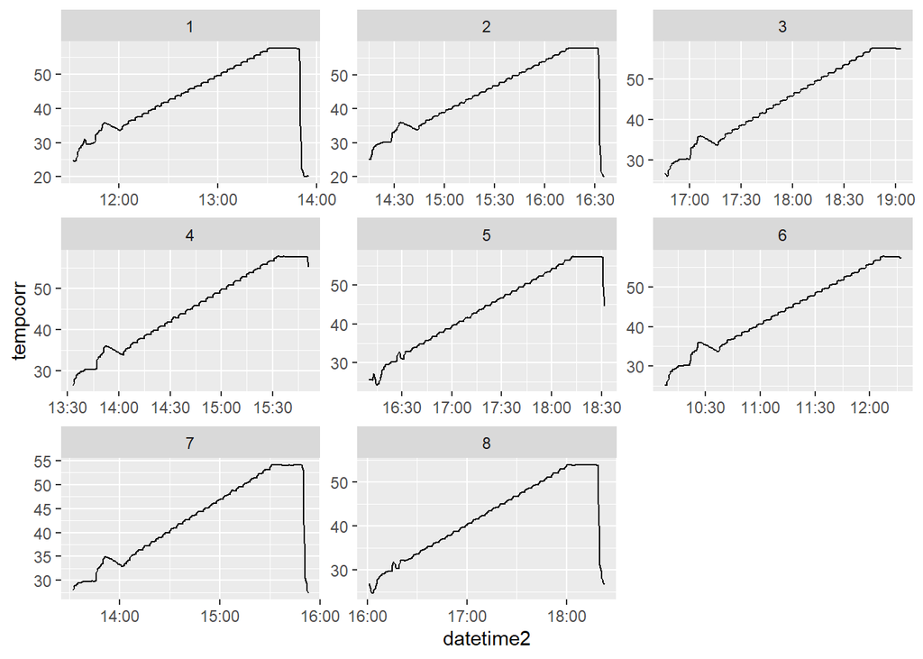

```r
ggplot(all_corr, aes(x=datetime2, y=tempcorr)) + geom_line()+ facet_wrap(~trial, scales="free")
```

## 7.4 Estimating temperature slope for each trial

### 7.4.1 Without removing bump at the begining of ramp

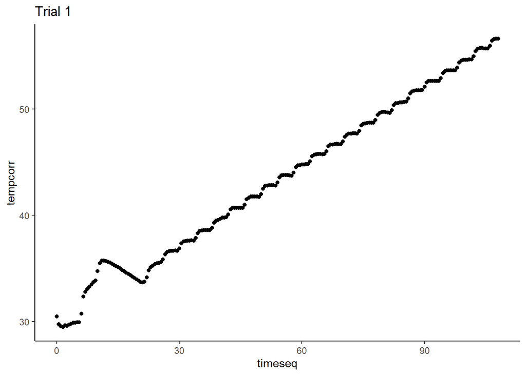

```r
# Trial 1
r1<-all_corr %>%
  filter(trial==1,
         datetime2 >= ymd_hms("2022-10-19 11:40:00") &
                               datetime <= ymd_hms("2022-10-19 13:28:00"))   %>%
  mutate(timeseq=seq(from=0, to=108,by=0.5))

ggplot(r1, aes(x=timeseq,y=tempcorr))+
  geom_point()+theme_classic()+ggtitle("Trial 1")
```

```r
lmtemp<-lm(tempcorr~timeseq, data=r1)
sl1<-lmtemp$coefficients[2]
round(sl1, digits=2)
```

```
## timeseq
##    0.24
```

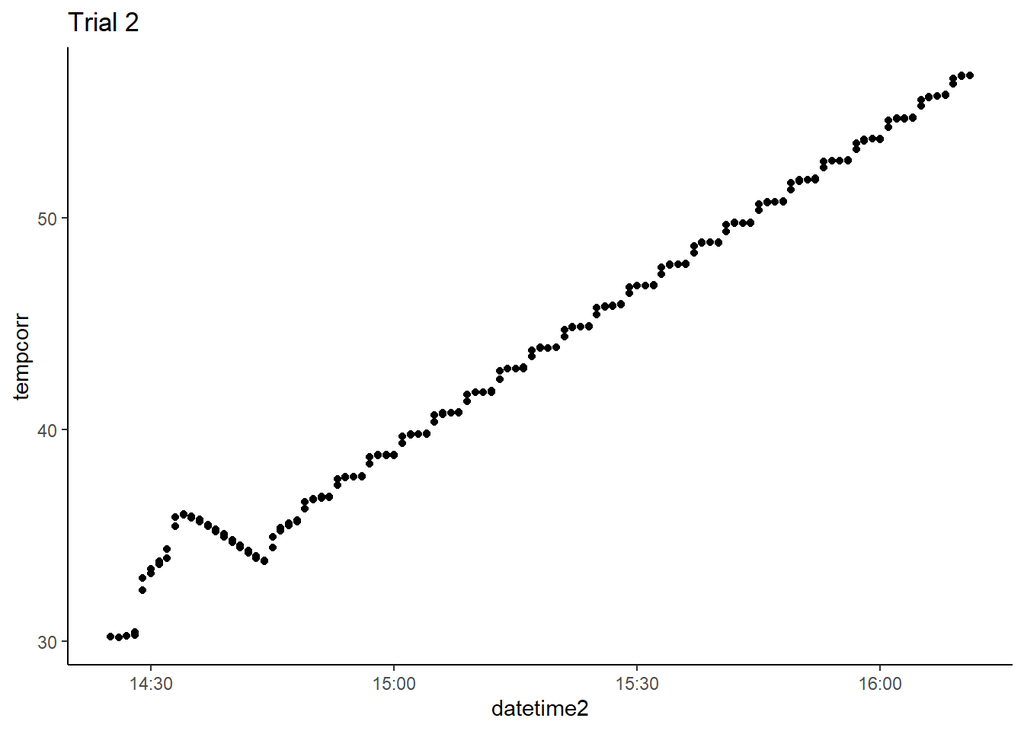

```r
# Trial 2
r2<-all_corr %>%
  filter(trial==2,
         datetime2 >= ymd_hms("2022-10-19 14:25:00") &
                               datetime <= ymd_hms("2022-10-19 16:11:00"))   %>%
  mutate(timeseq=seq(from=0, to=106,by=0.5))

ggplot(r2, aes(x=datetime2,y=tempcorr))+
  geom_point()+theme_classic()+ggtitle("Trial 2")
```

```r
lmtemp<-lm(tempcorr~timeseq, data=r2)
sl2<-lmtemp$coefficients[2]
round(sl2, digits=2)
```

```
## timeseq
##    0.24
```

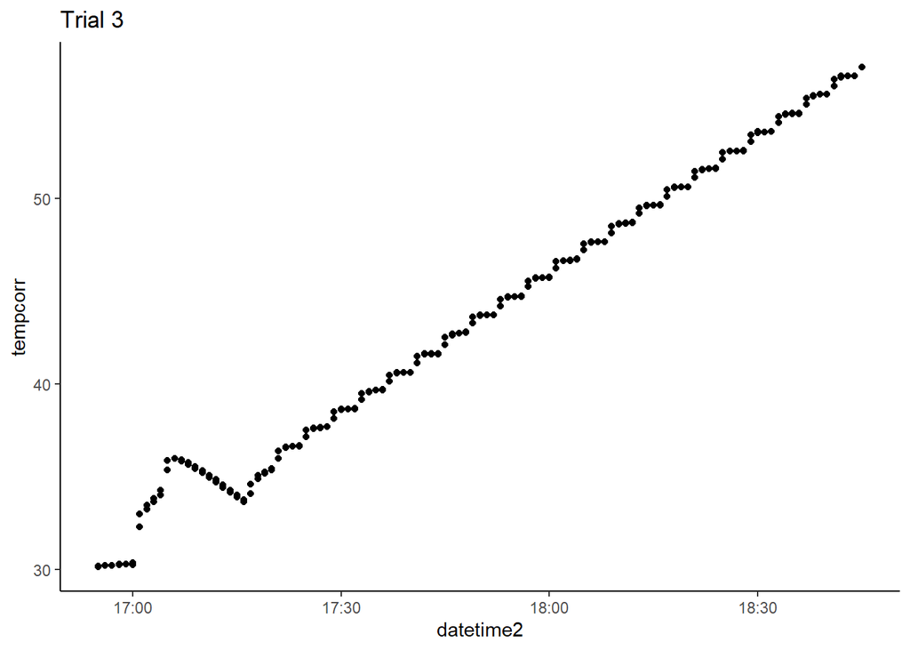

```r
# Trial 3
r3<-all_corr %>%
  filter(trial==3,
         datetime2 >= ymd_hms("2022-10-19 16:55:00") &
                               datetime <= ymd_hms("2022-10-19 18:45:00"))   %>%
  mutate(timeseq=seq(from=0, to=110,by=0.5))

ggplot(r3, aes(x=datetime2,y=tempcorr))+
  geom_point()+theme_classic()+ggtitle("Trial 3")
```

```r
lmtemp<-lm(tempcorr~timeseq, data=r3)
sl3<-lmtemp$coefficients[2]
round(sl3, digits=2)
```

```
## timeseq
##    0.24
```

```r
## FALTA continuar revisando slopes de trials 4-8


#slopes<-as.data.frame(c(sl1, sl2, sl3, sl4, sl5,sl6,sl7,sl8,sl9,sl10,sl11,sl12,sl13))
#colnames(slopes)<-"uncorr"
```

## 7.5 Creating dataframe for behavior data

```r
trial<-c(1,1,2,2,3,3,4,4,4,5,5,5,7,7,8,8,8,6,6,6)
ind<-c(236,157,358,366,357,365,348,369,142,359,368,347,252,363,259,254,39,261,362,361)
stage<-c("Female","Female", "Female", "Male", "Tritonymph","Male", "Tritonymph", "Male", "Female","Female", "Male","Tritonymph","Female","Male","Female", "Female","Female","Tritonymph","Male", "Female"  )
place<-c("side", "bottom", "bottom", "side", "bottom", "side",  "bottom", "bottom", "bottom", "side", "side",  "bottom", "bottom", "bottom", "bottom", "bottom", "bottom","bottom","out of focus", "side")
rigor.sec<-c((1*3600)+(34*60)+45-34,
             (1*3600)+(21*60)+48-34,
             (1*3600)+(19*60)+58-13,
             (1*3600)+(25*60)+28-13,
             (1*3600)+(24*60)+06-14,
             (1*3600)+(38*60)+38-14,
             (1*3600)+(29*60)+39-15,
             (1*3600)+(31*60)+55-15,
             (1*3600)+(25*60)+45-15,
             (1*3600)+(39*60)+31-8,
             (1*3600)+(39*60)+47-8,
             (1*3600)+(15*60)+49-8,
             (1*3600)+(17*60)+59-6,
             (1*3600)+(24*60)+27-6,
             (1*3600)+(10*60)+22-19,
             (1*3600)+(19*60)+52-19,
             (1*3600)+(19*60)+58-19,
             (1*3600)+(15*60)+47-20,
             0,
             (1*3600)+(39*60)+27-20)

beh<-data.frame(trial, ind, stage, place,rigor.sec)

#Getting the begining of the trial and calculating the final time where heat rigot occurred


timeseq<-all_corr %>%
  group_by(trial) %>%
  mutate(logtime=seq(from=0,to=(n()-1)/2, by=0.5))


all_corr_beg<-timeseq %>%
  #select(c("date", "trial", "channel", "ind", "stage", "weight", "ramp")) %>% #selecting the more relevant variables
  group_by(trial)%>% #Grouping by individual
  filter(row_number()==1) %>% #getting just the first row for each individual
  right_join(beh, by="trial") %>% #mergin the dataframes
  mutate(rigor=datetime2+rigor.sec) %>%
  rename("time.beg"="datetime2")%>%
  select(c(trial:time.beg,ind:rigor))

# Getting the temperatures associated with the heat rigor
#Merging the temperatures
heatrig<-difference_left_join(all_corr_beg,timeseq, by=c("rigor"="datetime2"), max_dist=30)%>% #Merges dataframes based on the closest logtime value (30 seconds) %>%
  group_by(ind)%>%
summarize(tempcorr2=mean(tempcorr),
          logtime2=mean(logtime)) %>%
  right_join(beh)%>%
  ungroup()%>%
  mutate(stage=fct_relevel(stage, "Tritonymph",  "Male", "Female"))%>%
  filter(ind!=362) #Individuals whose heat rigot was not determined

meanrigt<-mean(heatrig$tempcorr2)
meanrigt
```

```
## [1] 48.23719
```

```r
meanrigtime<-mean(heatrig$logtime2)
meanrigtime
```

```
## [1] 85.51316
```

```r
#the Topt is 44.25 (±0.16, SE) across all life stages (Based on the estimations done in a separate script)
#Mean logtime topt: 68.62526 +/- 0.56(standard error) (Based on the estimations done in a separate script)
```

## 7.6 Plotting to assess the variability of the heat rigor estimates

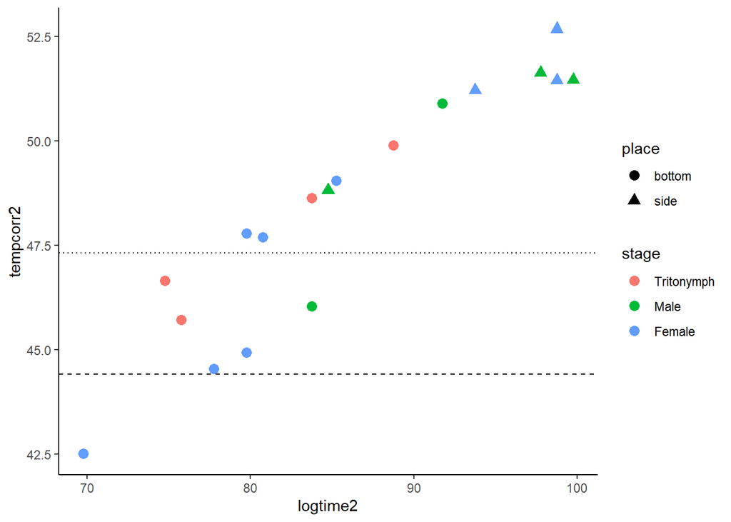

```r
ggplot(heatrig, aes(x=logtime2, y=tempcorr2, color=stage, shape=place))+
  geom_point(size=3)+
  theme_classic()+
  geom_hline(yintercept=44.25+0.16, linetype="dashed")+ #upper limit of the SE
  geom_hline(yintercept=47.31, linetype="dotted") #maximum recorded topt
```

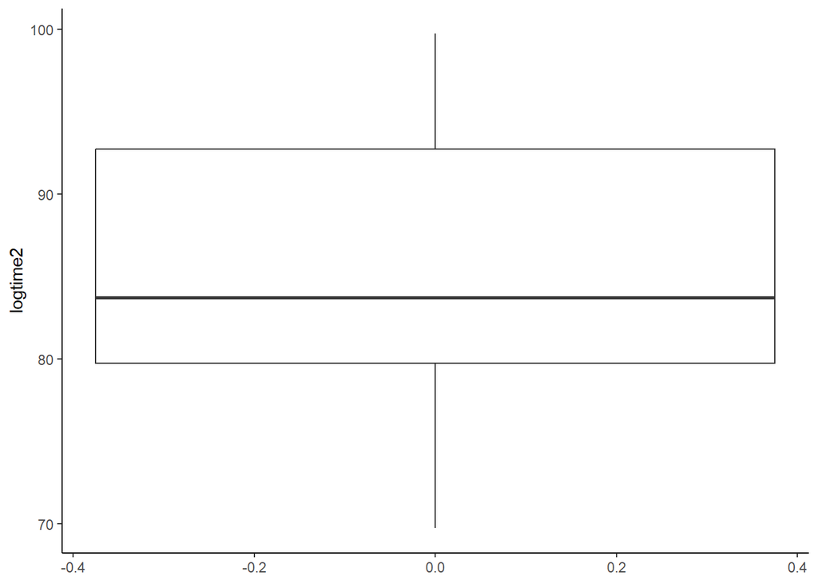

```r
ggplot(heatrig, aes(y=logtime2))+geom_boxplot()+theme_classic()
```

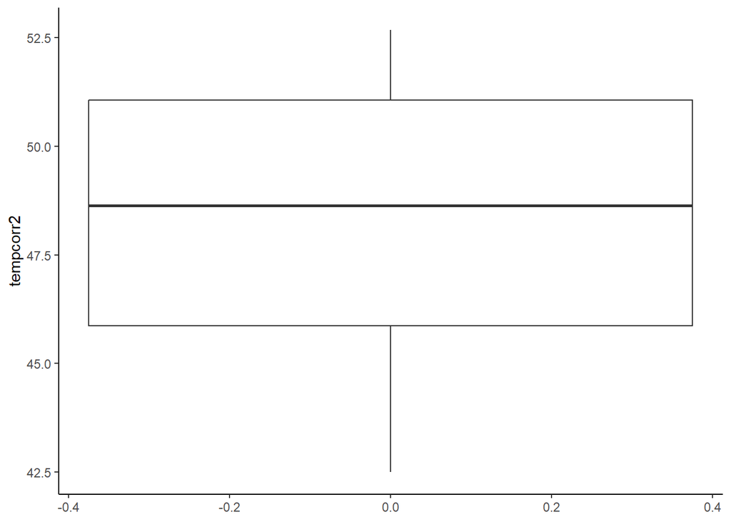

```r
ggplot(heatrig, aes(y=tempcorr2))+geom_boxplot()+theme_classic()
```

> This shows that the estimate heat rigor is congruent with what one would expect: it should happen after and at a higher temperature than the Topt or Tmetmax. However, since a few individuals moved around and climb to the walls of the well in the thermal block, potentially being exposed to slighlty different temperatures, I wanted to see if removing them would change the data significantly:

## 7.7 Filtering for only those that stayed at the bottom of the well

```r
heatrig2<-heatrig%>%
  filter(place=="bottom")

meanrigt<-mean(heatrig2$tempcorr2)
meanrigt
```

```
## [1] 46.86565
```

```r
setemp<-sd(heatrig2$tempcorr2)/sqrt(length(heatrig2$tempcorr2))

meanrigtime<-mean(heatrig2$logtime2)
meanrigtime
```

```
## [1] 80.86538
```

```r
setime<-sd(heatrig2$logtime2)/sqrt(length(heatrig2$logtime2))


#the Topt is 44.25 (±0.16, SE) across all life stages
#Mean logtime topt: 68.62526 +/- 0.56(standard error)
```

> These estimates are lower but more conservative (since all individuals stayed in the same place within the well), so I decided to use this estimates as the final heat rigor data

### 7.7.1 Plotting of the final heat rigor data

```r
# Getting colors for stages
hex <- scales::hue_pal()(5)
hex # The last 3 are the ones I should use
```

```
## [1] "#F8766D" "#A3A500" "#00BF7D" "#00B0F6" "#E76BF3"
```

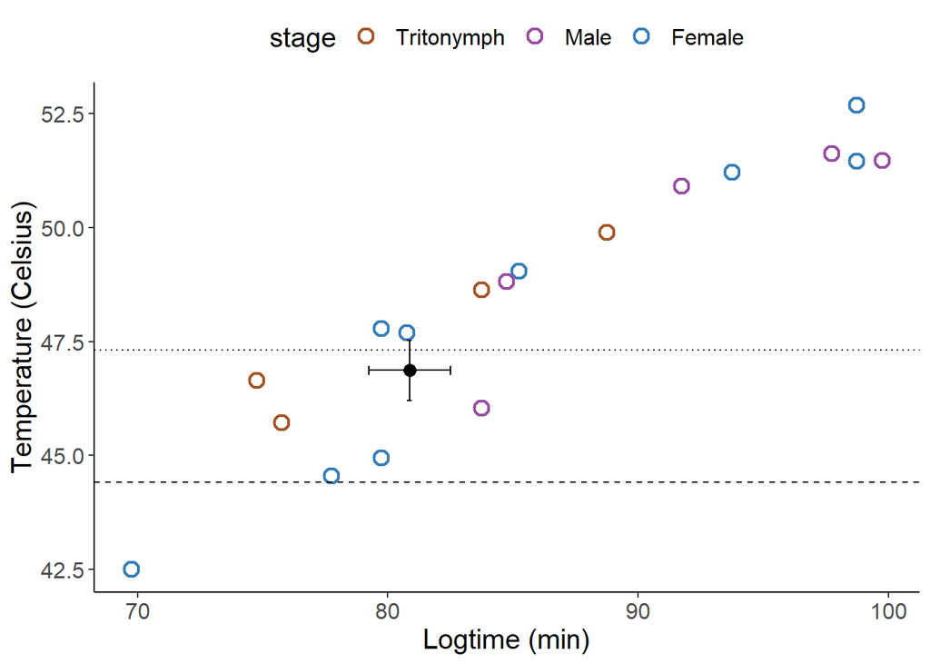

```r
rigor<-ggplot(heatrig, aes(x=logtime2, y=tempcorr2, color=stage))+
  geom_point(size=3, shape=1, stroke=1.2)+
  geom_hline(yintercept=44.25+0.16, linetype="dashed")+ #upper limit of the SE
  geom_hline(yintercept=47.31, linetype="dotted") + #maximum recorded topt+
  theme_classic()+ theme(text = element_text(size = 15))+
  scale_color_manual(values=c("#a65628", "#984ea3", "#377eb8"))+
  xlab("Logtime (min)")+
  ylab("Temperature (Celsius)")+
  geom_point(aes(y = meanrigt, x=meanrigtime),color = "black", size = 3) +
  geom_errorbar(aes(x=meanrigtime, ymin = meanrigt-setemp, ymax = meanrigt+setemp), color = "black", inherit.aes = FALSE, width=0.2) +
  geom_errorbarh(aes(y=meanrigt, xmin = meanrigtime-setime, xmax = meanrigtime+setime), color = "black", inherit.aes = FALSE, height=0.2)+
  theme(legend.position = "top")
rigor
```

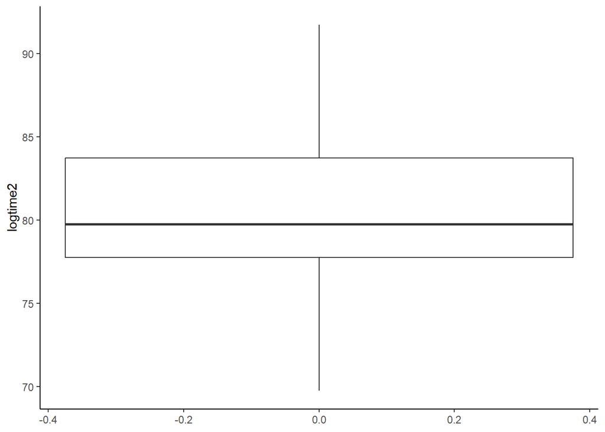

```r
ggsave(plot=last_plot(),filename="Heatrigor.jpg",  path="Outputs/")

ggplot(heatrig2, aes(y=logtime2))+geom_boxplot()+theme_classic()
```

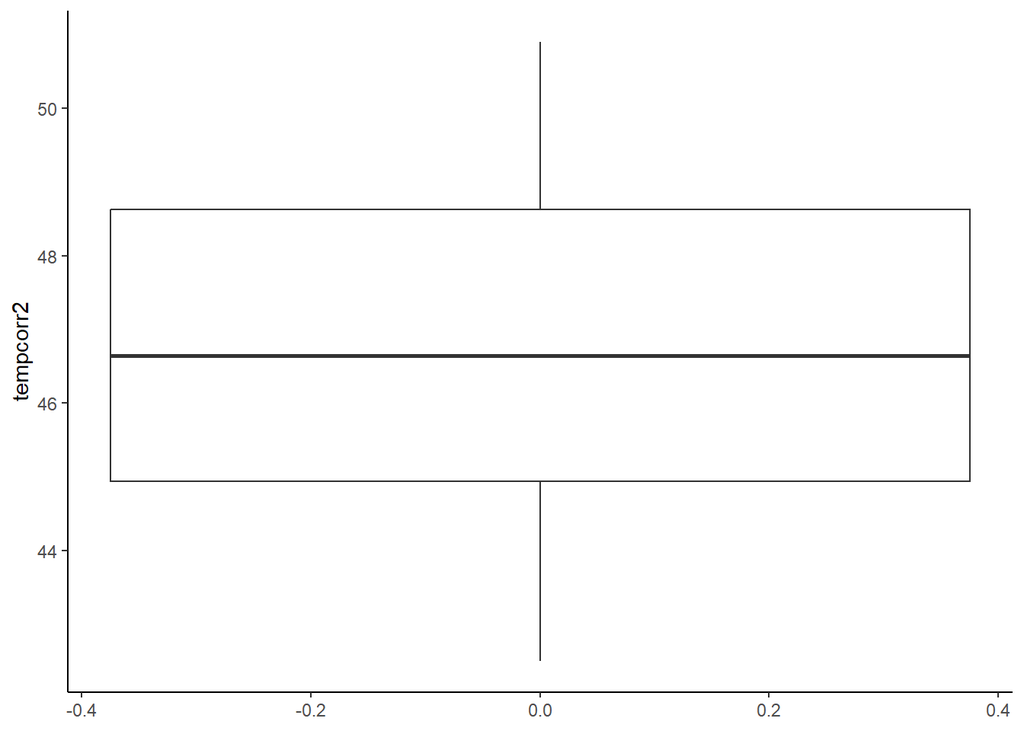

```r
ggplot(heatrig2, aes(y=tempcorr2))+geom_boxplot()+theme_classic()
```